# 2022-2023 1o teste (turno 1)

A Freitas, Conceiçao Lopes, Luís Silva

março/2023

Para controlar o que globalmente surge:

```r
knitr::opts_chunk$set(echo = TRUE, results='show', message=FALSE, fig.show='show')
```

**olá**

```r
#LEITURA DOS dados

#  Session => Set working diretory => To source file location

#Leitura dos dados
#setwd("D:/Aulas/1CicloBolonha/EstatisticaBiomedica/2022-23/ProvasAvaliacao")

#Funções de calculo de quantil conforme aulas
Quantil=function(x,p)
{n=length(x)
if(n*p- round(n*p)==0){res=(sort(x)[n*p]+ sort(x)[n*p+1])/2}
else{res=sort(x)[floor(n*p+1)]}
res
}

Mediana=function(x)
{n=length(x)
if(n/2 - round(n/2)==0){res=(sort(x)[n/2]+ sort(x)[n/2+1])/2}else{res=sort(x)[(n+1)/2]}
res
}

Quartil1=function(x)
{n=length(x)
if(n/2 - round(n/2)==0){res=Mediana(sort(x)[1:(n/2)])}else{res=Mediana(sort(x)[1:((n-1)/2)])}
res
}


Quartil3=function(x)
{n=length(x)
if(n/2 - round(n/2)==0){res=Mediana(sort(x)[(n/2+1):n])}else{res=Mediana(sort(x)[((n+3)/2):n])}
res
}

BigodeD=function(x)
{H=Quartil3(x)-Quartil1(x)
M=Quartil3(x)+1.5*H
max(x[x<M])
}

#chamar bibliotecas necessárias
library(knitr)  # para construir tabelas
```

# Capítulo EstatDesc -Q1- GolfinhosSelvagens - Medidas amostrais dados nao agrupados- CLOZE

3 variantes

```r
#Dados
xx1=matrix(c(69.0,233,150,168.0,160.0,162.0,138.0,114.0,123.0,151.0),nrow=1)

xxx1=matrix(c(xx1[-c(4,9)],181,121), nrow=1)

xx=list(xx1,xx1+4,xxx1)
variavel=c("peso", "volume", "peso","volume")
variancia=c(sd(xx[[1]])^2,(sd(xx[[2]])^2) * 9/10, sd(xx[[3]])^2)
textovar= c("**corrigida**","**não corrigida**","**corrigida**")
valorpercentil=c(60,40,30)
#SOLUTION
```

## variante 01

Anualmente, é registada informação sobre características corporais de golfinhos selvagens *Tursiops truncatus* que dão à costa num dado país. No ano passado, relativamente aos 10 golfinhos que deram à costa, registaram-se os seguintes valores de peso (numa dada unidade de medida):

| 69 | 233 | 150 | 168 | 160 | 162 | 138 | 114 | 123 | 151 |
| --- | --- | --- | --- | --- | --- | --- | --- | --- | --- |

**(1)** A variável em estudo corresponde {1:MULTICHOICE_S:= ao peso de um golfinho ~aos 10 golfinhos observados ~às características corporais de 10 golfinhos ~ao volume de um golfinho} a qual é registada na escala {1:MULTICHOICE_S:=de razão~nominal~ordinal~intervalar}

**(2)** A frequência absoluta acumulada do valor 160 na amostra é igual a {2:NUMERICAL:=7:0} (use até 1 casa decimal)

**(3)** Relativamente à variável em estudo, indique os valores das seguintes medidas amostrais:

- média = {1:NUMERICAL:=146.8:0.005} (use até 2 casas decimais)
- **variância** **corrigida** = {2:NUMERICAL:=1787.2888889:0.05} (use **4** casas decimais)
- percentil de ordem 60 = {1:NUMERICAL:=155.5:0.005} (use 2 casas decimais) Daqui se conclui que pelo menos {1:NUMERICAL:=40:0} (use número inteiro) % das observações da amostra são maiores ou iguais a esse valor.

**(4)** Se construísse uma caixa de bigodes associada a esta amostra, o bigode à direita iria até ao **valor** {3:NUMERICAL:=168:0}

### feedback

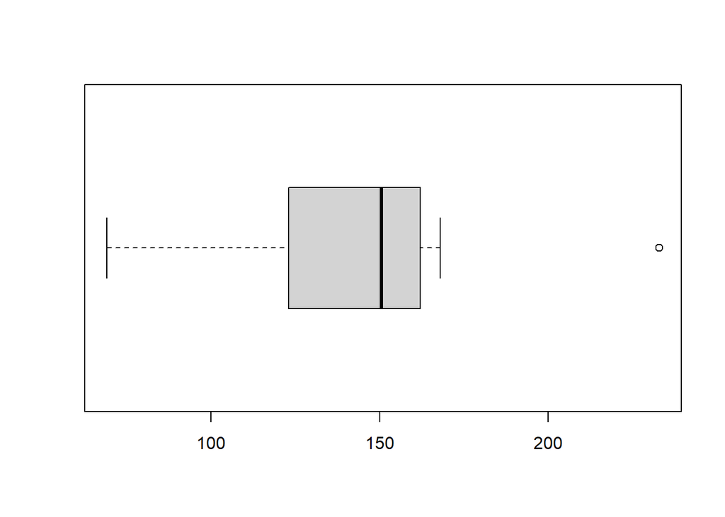

## variante 02

**(1)** A variável em estudo corresponde {1:MULTICHOICE_S:= ao volume de um golfinho ~aos 10 golfinhos observados ~às características corporais de 10 golfinhos ~ao peso de um golfinho} a qual é registada na escala {1:MULTICHOICE_S:=de razão~nominal~ordinal~intervalar}

**(2)** A frequência absoluta acumulada do valor 164 na amostra é igual a {2:NUMERICAL:=7:0} (use até 1 casa decimal)

**(3)** Relativamente à variável em estudo, indique os valores das seguintes medidas amostrais:

- média = {1:NUMERICAL:=150.8:0.005} (use até 2 casas decimais)
- **variância** **não corrigida** = {2:NUMERICAL:=1608.56:0.05} (use **4** casas decimais)
- percentil de ordem 40 = {1:NUMERICAL:=148:0.005} (use 2 casas decimais) Daqui se conclui que pelo menos {1:NUMERICAL:=60:0} (use número inteiro) % das observações da amostra são maiores ou iguais a esse valor.

**(4)** Se construísse uma caixa de bigodes associada a esta amostra, o bigode à direita iria até ao **valor** {3:NUMERICAL:=172:0}

### feedback

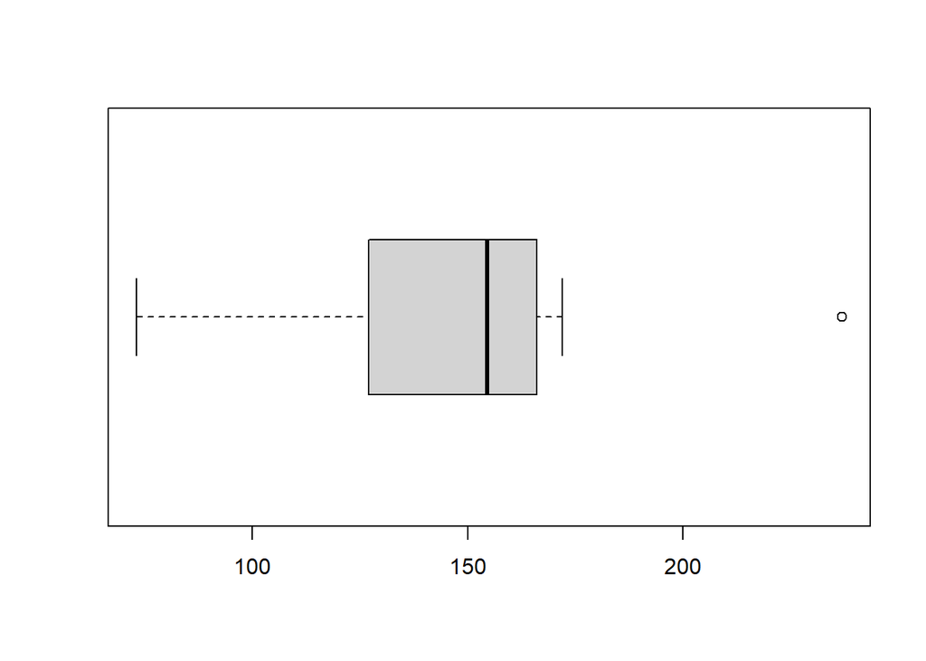

## variante 03

Anualmente, é registada informação sobre características corporais de golfinhos selvagens *Tursiops truncatus* que dão à costa num dado país. No ano passado, relativamente aos 10 golfinhos que derão à costa, registaram-se os seguintes valores de peso (numa dada unidade de medida):

| 69 | 233 | 150 | 160 | 162 | 138 | 114 | 151 | 181 | 121 |
| --- | --- | --- | --- | --- | --- | --- | --- | --- | --- |

**(1)** A variável em estudo corresponde {1:MULTICHOICE_S:= ao peso de um golfinho ~aos 10 golfinhos observados ~às características corporais de 10 golfinhos ~ao volume de um golfinho} a qual é registada na escala {1:MULTICHOICE_S:=de razão~nominal~ordinal~intervalar}

**(2)** A frequência absoluta acumulada do valor 162 na amostra é igual a {2:NUMERICAL:=8:0} (use até 1 casa decimal)

**(3)** Relativamente à variável em estudo, indique os valores das seguintes medidas amostrais:

- média = {1:NUMERICAL:=147.9:0.005} (use 2 casas decimais)
- **variância** **corrigida** = {2:NUMERICAL:=1876.9888889:0.05} (use **4** casas decimais)
- percentil de ordem 30 = {1:NUMERICAL:=129.5:0.005} (use 2 casas decimais) Daqui se conclui que pelo menos {1:NUMERICAL:=70:0} (use número inteiro) % das observações da amostra são maiores ou iguais a esse valor.

**(4)** Se construísse uma caixa de bigodes associada a esta amostra, o bigode à direita iria até ao **valor** {3:NUMERICAL:=181:0}

### feedback

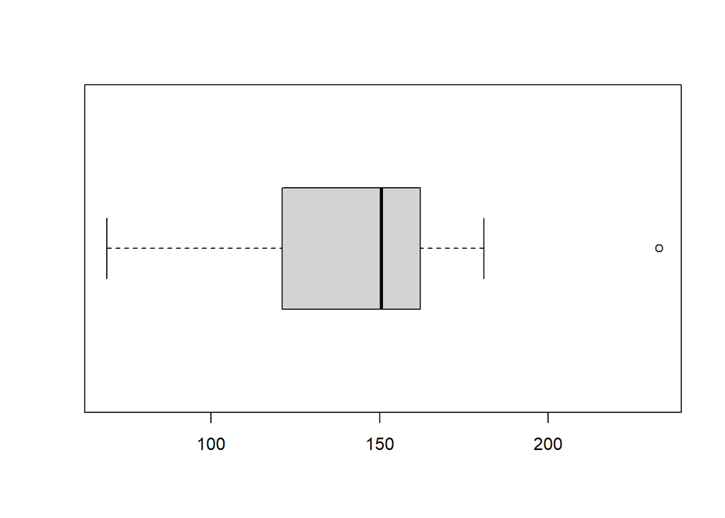

# Capítulo EstDesc -Q2- GolfinhosSelvagens - Interpretações de Histogramas e de medidas- CLOZE

2 variantes

```r
set.seed(5)
Idade1=c(rnorm(20,13,2),rnorm(10,14,0.5))


set.seed(6)
Idade2=c(rnorm(40,12.5,0.5),rnorm(20,14,2)) +1
Idade2=Idade2[-c(1:12,30:34,55)]


Idade=list(Idade1,Idade2)
classe=c(8,8)
ampl=c(1,1)
ad=c(2,1)
valor=NULL
for (i in 1:2){valor[i]=c(round(Mediana(Idade[[i]]),0)+ad[i])}
altura=c(8,16)

texto2=c("ou eram mais novos", "menos, sendo que apenas 1 era tinha 15 anos")
LogCorretoFrase1= c("falsa","verdadeira")
LogErradoFrase1= c("verdadeira","falsa")

Rmoda=c(7,24)

#SOLUTION
```

## variante 01

Anualmente, é registada informação sobre características corporais de golfinhos selvagens *Tursiops truncatus* que dão à costa num dado país.

**(1)** O gráfico seguinte apresenta a distribuição das idades dos 30 espécimes de golfinhos selvagens *Tursiops truncatus* que deram à costa em 2020.

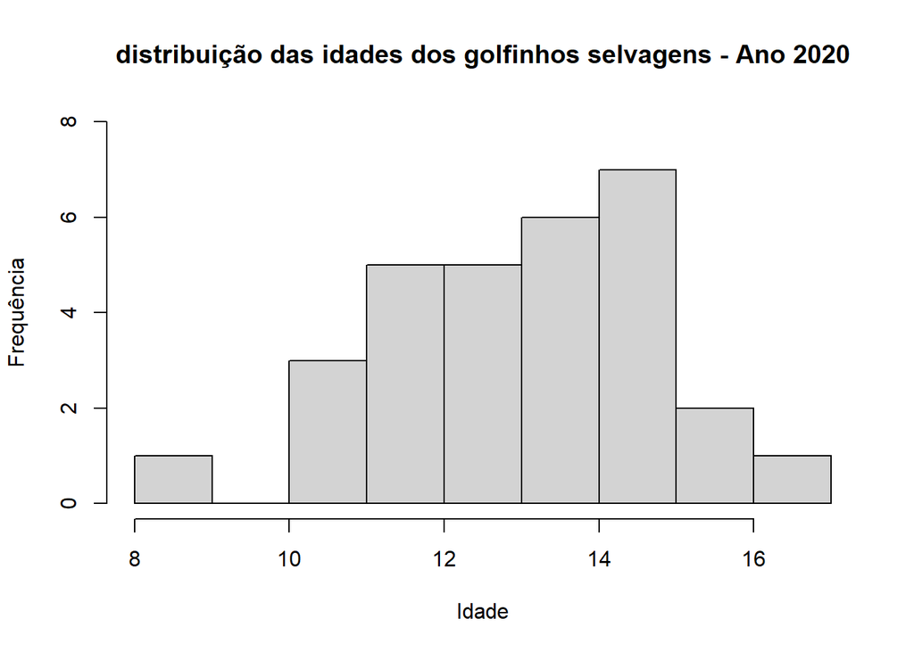

**(1.a)** Sobre os dados observados em 2020, o primeiro quartil das idades pertence à classe de {:NUMERICAL:=11:0} a {:NUMERICAL:=12:0}

**(1.b)** Com base no gráfico de 2020, complete as frases:

- A percentagem de golfinhos com idade superior a 15 anos é de aproximadamente {:MULTICHOICE_S:=10% ~6.7% ~2%~3%}.
- Existem 20 golfinhos com idade inferior ou igual a {:MULTICHOICE_S:=14 ~16 ~15} anos.
- A amplitude de cada classe é igual a {:MULTICHOICE_S:=1 ~%-25%2} (desconta 25% da cotação se errada)

**(2)** Curiosamente, no ano seguinte, em **2021**, verificou-se que [15, 18] é o intervalo interquartil das idades (em anos) dos golfinhos selvagens que deram à costa.

Identifique o valor lógico das seguintes frases relativas ao ano de **2021**:

(NOTA: **em cada frase, desconta 25% se errada**):

- Frase {1:MULTICHOICE_S:=falsa ~%-25%verdadeira }: A mediana das idades dos golfinhos que deram à costa é necessariamente maior a 15 anos.
- Frase {1:MULTICHOICE_S:=falsa ~%-25%verdadeira }: A média das idades dos golfinhos que deram à costa será sempre um valor entre 15 e 18 anos.
- Frase {1:MULTICHOICE_S:=verdadeira ~%-25%falsa }: Cerca de 50% dos golfinhos que deram à costa tinham idades entre 15 e 18 anos.

### feedback

## variante 02

Anualmente, é registada informação sobre características corporais de golfinhos selvagens *Tursiops truncatus* que dão à costa num dado país.

**(1)** O gráfico seguinte apresenta a distribuição das idades dos 42 espécimes de golfinhos selvagens *Tursiops truncatus* que deram à costa em 2020.

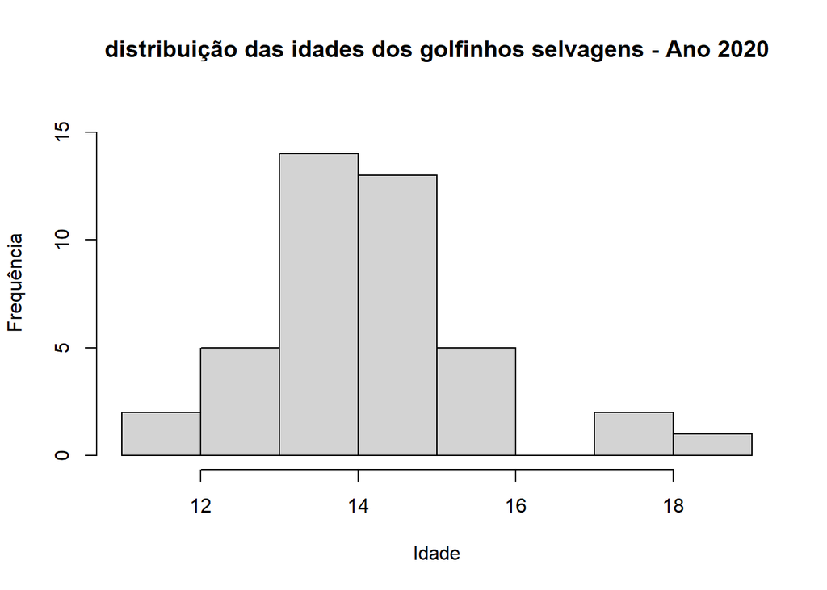

**(1.a)** Sobre os dados observados em 2020, o primeiro quartil das idades pertence à classe de {:NUMERICAL:=13:0} a {:NUMERICAL:=14:0}

**(1.b)** Com base no gráfico de 2020, complete as frases:

- A percentagem de golfinhos com idade superior a 15 anos é de aproximadamente {:MULTICHOICE_S:=19% ~11.9% ~5%~8%}.
- Existem 34 golfinhos com idade inferior ou igual a {:MULTICHOICE_S:=15 ~16 ~14} anos.
- As classes apresentam amplitudes {:MULTICHOICE_S:=iguais ~%-25%diferentes} entre si (desconta 25% da cotação se errada)

**(2)** Curiosamente, no ano seguinte, em **2021**, verificou-se que [15, 18] é o intervalo interquartil das idades (em anos) dos golfinhos selvagens que deram à costa.

Identifique o valor lógico das seguintes frases relativas ao ano de **2021**:

(NOTA: **em cada frase, desconta 25% se errada**):

- Frase {1:MULTICHOICE_S:=verdadeira ~%-25%falsa }: A mediana das idades dos golfinhos que deram à costa é necessariamente maior ou igual a 15 anos.
- Frase {1:MULTICHOICE_S:=falsa ~%-25%verdadeira }: A média das idades dos golfinhos que deram à costa será sempre um valor entre 15 e 18 anos.
- Frase {1:MULTICHOICE_S:=falsa ~%-25% verdadeira }: cerca de 25% dos golfinhos que deram à costa tenham idades entre 15 e 18 anos.

### feedback

# Capítulo DistProb -Q3- Porcos da India - Binomial e Normal - CLOZE

3 variantes

```r
Valorn=c(20,25,30)
Valorp=c(0.05,0.04,0.06)
Valormedia=c(36,30,25)
Valorvar=c(4,9,16)

#SOLUTION
```

## variante 01

Um laboratório de investigação científica adquiriu em fevereiro um conjunto de 20 porquinhos da Índia para um estudo comportamental prolongado. Os porquinhos da Índia são muito sensíveis a problemas respiratórios causados por pó ou infeções por bactérias e assume-se que a probabilidade de um animal desenvolver um problema deste tipo é de 0.05.

**(1)** A v.a. $X$ que representa o número de porquinhos da Índia que desenvolvem problemas respiratórios {:MULTICHOICE_S:= entre 20 porquinhos da Índia~por mês ~por laboratório } segue uma distribuição Binomial com $n$={:NUMERICAL:=20:0} e $p$=0.05.

Assim,

- o valor esperado $E(7X-3)$ é igual a {3:NUMERICAL:=4:0.005} (use até 2 casas decimais)
- a probabilidade de um porquinho da Índia, do conjunto dos porquinhos adquiridos, desenvolver problemas respiratórios é igual a {2:NUMERICAL:=0.3773536:0.0005} (use 3 casas decimais)
- a probabilidade de menos de 3 porquinhos da Índia, do conjunto dos porquinhos adquiridos, desenvolver problemas respiratórios é igual a {3:NUMERICAL:=0.9245163:0.0005} (use 3 casas decimais)

**(2)** A v.a. $T$, que representa o tempo (em horas) que um porquinho da Índia demora a demonstrar problemas respiratórios após estar infetado, segue uma distribuição normal de média 36 e variância 4.

Assim,

- selecionado ao acaso um porquinho da Índia infetado, a probabilidade de este demorar exatamente um dia (24 horas) a demonstrar problemas respiratórios é igual a {:NUMERICAL:=0:0.005} (use até 2 casas decimais)
- selecionado ao acaso 20 porquinhos da Índia infetados, a probabilidade da média dos tempos de demora a demonstrar problemas respiratórios desses 20 porquinhos seja superior a 35 horas é igual a {3:NUMERICAL:=0.9873263:0.005} (use 3 casas decimais)

### feedback

## variante 02

Um laboratório de investigação científica adquiriu em fevereiro um conjunto de 25 porquinhos da Índia para um estudo comportamental prolongado. Os porquinhos da Índia são muito sensíveis a problemas respiratórios causados por pó ou infeções por bactérias e assume-se que a probabilidade de um animal desenvolver um problema deste tipo é de 0.04.

**(1)** A v.a. $X$ que representa o número de porquinhos da Índia que desenvolvem problemas respiratórios {:MULTICHOICE_S:= entre 25 porquinhos da Índia~por mês ~por laboratório } segue uma distribuição Binomial com $n$={:NUMERICAL:=25:0} e $p$=0.04.

Assim,

- o valor esperado $E(7X+3)$ é igual a {3:NUMERICAL:=10:0.005} (use até 2 casas decimais)
- a probabilidade de um porquinho da Índia, do conjunto dos porquinhos adquiridos, desenvolver problemas respiratórios é igual a {2:NUMERICAL:=0.3754132:0.0005} (use 3 casas decimais)
- a probabilidade de mais de 3 porquinhos da Índia, do conjunto dos porquinhos adquiridos, desenvolver problemas respiratórios é igual a {3:NUMERICAL:=0.0165216:0.0005} (use 3 casas decimais)

**(2)** A v.a. $T$, que representa o tempo (em horas) que um porquinho da Índia demora a demonstrar problemas respiratórios após estar infetado, segue uma distribuição normal de média 30 e variância 9.

Assim,

- selecionado ao acaso um porquinho da Índia infetado, a probabilidade de este demorar exatamente dois dias (48 horas) a demonstrar problemas respiratórios é igual a {:NUMERICAL:=0:0.005} (use até 2 casas decimais)
- selecionado ao acaso 25 porquinhos da Índia infetados, a probabilidade da média dos tempos de demora a demonstrar problemas respiratórios desses 25 porquinhos seja superior a 29 horas é igual a {3:NUMERICAL:=0.9522096:0.005} (use 3 casas decimais)

### feedback

## variante 03

Um laboratório de investigação científica adquiriu em fevereiro um conjunto de 30 porquinhos da Índia para um estudo comportamental prolongado. Os porquinhos da Índia são muito sensíveis a problemas respiratórios causados por pó ou infeções por bactérias e assume-se que a probabilidade de um animal desenvolver um problema deste tipo é de 0.06.

**(1)** A v.a. $X$ que representa o número de porquinhos da Índia que desenvolvem problemas respiratórios {:MULTICHOICE_S:= entre 30 porquinhos da Índia~por mês ~por laboratório } segue uma distribuição Binomial com $n$={:NUMERICAL:=30:0} e $p$=0.06.

Assim,

- o valor esperado $E(3X+7)$ é igual a {3:NUMERICAL:=12.4:0.005} (use até 2 casas decimais)
- a probabilidade de um porquinho da Índia, do conjunto dos porquinhos adquiridos, desenvolver problemas respiratórios é igual a {2:NUMERICAL:=0.2992129:0.0005} (use 3 casas decimais)
- a probabilidade de menos de 3 porquinhos da Índia, do conjunto dos porquinhos adquiridos, desenvolver problemas respiratórios é igual a {3:NUMERICAL:=0.7323995:0.0005} (use 3 casas decimais)

**(2)** A v.a. $T$, que representa o tempo (em horas) que um porquinho da Índia demora a demonstrar problemas respiratórios após estar infetado segue uma distribuição normal de média 25 e variância 16.

Assim,

- selecionado ao acaso um porquinho da Índia infetado, a probabilidade de este demorar exatamente três dias (72 horas) a demonstrar problemas respiratórios é igual a {:NUMERICAL:=0:0.005} (use até 2 casas decimais)
- selecionado ao acaso 30 porquinhos da Índia infetados, a probabilidade da média dos tempos de demora a demonstrar problemas respiratórios desses 30 porquinhos seja inferior a 24 horas é igual a {3:NUMERICAL:=0.0854518:0.0005} (use até 3 casas decimais)

### feedback

# Capítulo DistProb -Q4- Porcos da India - Poisson - CLOZE

3 variantes

```r
ValorLambda=c(5,6,7)
ValorQu=c(10,12,14)
#SOLUTION
```

## variante 01

Um dos principais sintomas de problemas respiratórios em porquinhos da Índia é um número elevado de espirros por hora. Suponha que o número de espirros por hora de um porquinho da Índia doente (com problemas respiratórios) pode ser modelado por uma distribuição de Poisson de média 5.

Assim,

- a probabilidade de um porquinho da Índia doente dar mais do que 10 espirros numa hora é igual a {:NUMERICAL:=0.0136953:0.00005} (use 4 casas decimais)
- a probabilidade de um porquinho da Índia doente dar exatamente 120 espirros num dia (24 horas) é igual a {2:NUMERICAL:=0.036393:0.00005} (use 4 casas decimais)

### feedback

## variante 02

Um dos principais sintomas de problemas respiratórios em porquinhos da Índia é um número elevado de espirros por hora. Suponha que o número de espirros por hora de um porquinho da Índia doente (com problemas respiratórios) pode ser modelado por uma distribuição de Poisson de média 6.

Assim,

- a probabilidade de um porquinho da Índia doente dar mais do que 12 espirros numa hora é igual a {:NUMERICAL:=0.0088275:0.00005} (use 4 casas decimais)
- a probabilidade de um porquinho da Índia doente dar exatamente 132 espirros num dia (24 horas) é igual a {2:NUMERICAL:=0.0207446:0.00005} (use 4 casas decimais)

### feedback

## variante 03

Um dos principais sintomas de problemas respiratórios em porquinhos da Índia é um número elevado de espirros por hora. Suponha que o número de espirros por hora de um porquinho da Índia doente (com problemas respiratórios) pode ser modelado por uma distribuição de Poisson de média 7.

Assim,

- a probabilidade de um porquinho da Índia doente dar mais do que 14 espirros numa hora é igual a {:NUMERICAL:=0.0057172:0.00005} (use até 4 casas decimais)
- a probabilidade de um porquinho da Índia doente dar exatamente 140 espirros em 18 horas é igual a {2:NUMERICAL:=0.0159097:0.00005} (use 4 casas decimais)

### feedback